# Investigating scale dependency of KL divergence estimators

Niklas Hartung

2023-10-04

## Topic

Kullback-Leibler divergence is scale-invariant, i.e. if $X\sim P$, $Y\sim Q$, and $g(X)\sim \tilde{P}$, $g(Y)\sim \tilde{Q}$ for some transform $g$, then $D_{KL}(P||Q) = D_{KL}(\tilde{P},\tilde{Q})$.

The same doesn’t hold for *estimators of* Kullback-Leibler divergence, which will depend on whether $X_1,...,X_n$ and $Y_1,...,Y_m$ or $g(X_1),...,g(X_n)$ and $g(Y_1),...,g(Y_m)$ are used, i.e. $\hat D_{KL}(\mathbf X,\mathbf Y) \neq \hat D_{KL}(g(\mathbf X),g(\mathbf Y))$.

This property can be used to our advantage: if we find a transformed scale $g$ such that $\hat D_{KL}(g(\mathbf X),g(\mathbf Y))$ has better properties than on the original scale, we can use that estimator.

In particular, it seems reasonable to standardise distances in the different variables. Here, we explore whether transforming marginals to a uniform scale improves estimation. More precisely, consider a $d$-dimensional variable $x = (x_1,...,x_d)$ and let $\hat F_i$ denote the empirical cumulative distribution function of the $i$-th variable in the combined sample $(\mathbf X,\mathbf Y)$.  
We then set $g(x_1,...,x_d) := (F_1(x_1),...,F_d(x_d))$ and consider the transformed samples $g(\mathbf X)$ and $g(\mathbf Y)$.

## Simulation study

```r
library(kldest)
library(ggplot2)
```

### Scenario 1: independent 2D Gaussians

We first consider a 2D problem with different locations/scales on the two variables, and independent variables.

True KL divergence:

```r
mu1 <- c(2,0); sigma1 <- c(1,100)
mu2 <- c(0,10); sigma2 <- c(1,100)
kld_true <- kld_gaussian(mu1 = mu1, sigma1 = diag(sigma1), mu2 = mu2, sigma2 = diag(sigma2))
```

```r
nrep <- 100L
n <- 1000L
kld_orig <- numeric(nrep)
kld_unif <- numeric(nrep)
for (i in 1:nrep) {
    X <- cbind(rnorm(n, mean = mu1[1], sd = sqrt(sigma1[1])),
               rnorm(n, mean = mu1[2], sd = sqrt(sigma1[2])))
    Y <- cbind(rnorm(n, mean = mu2[1], sd = sqrt(sigma2[1])),
               rnorm(n, mean = mu2[2], sd = sqrt(sigma2[2])))
    X <- exp(X)
    Y <- exp(Y)

    kld_orig[i] <- kld_est_nn(X, Y)

    uXY <- to_uniform_scale(X, Y)

    kld_unif[i] <- kld_est_nn(X = uXY$X, Y = uXY$Y)
}
```

### Illustrations

Illustration of a sample on original scale

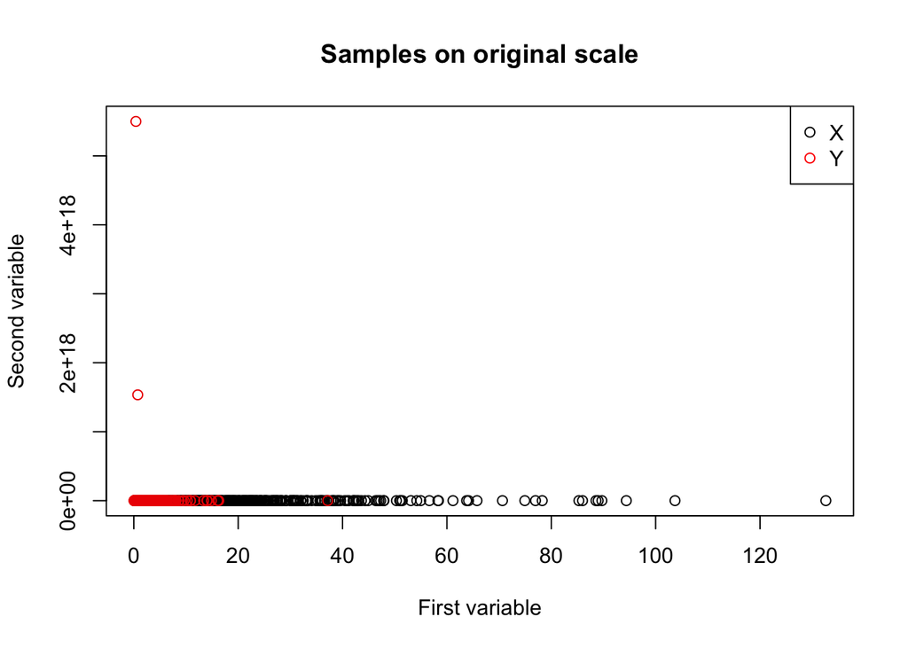

```r
plot(NA,
     xlim = range(c(X[,1],Y[,1])),
     ylim = range(c(X[,2],Y[,2])),
     xlab = "First variable",
     ylab = "Second variable",
     main = "Samples on original scale")
points(X[,1], X[,2])
points(Y[,1], Y[,2], col="red2")
legend("topright", legend = c("X","Y"), col = c("black","red"), pch = 1)
```

Illustration of a sample on uniform scale

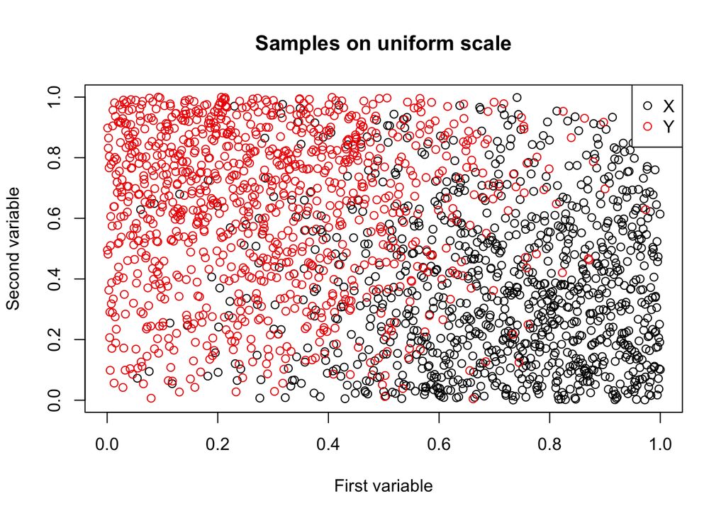

```r
plot(NA,
     xlim = 0:1,
     ylim = 0:1,
     xlab = "First variable",
     ylab = "Second variable",
     main = "Samples on uniform scale")
points(uXY$X[,1], uXY$X[,2])
points(uXY$Y[,1], uXY$Y[,2], col="red2")
legend("topright", legend = c("X","Y"), col = c("black","red"), pch = 1)
```

### Results

Format the results

```r
kld <- rbind(
    data.frame(kld = kld_orig, scale = "orig"),
    data.frame(kld = kld_unif, scale = "unif")
)
```

Display the results

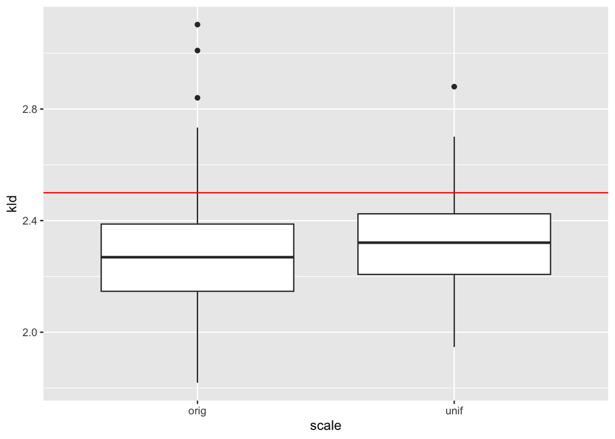

```r
ggplot(data = kld) + geom_boxplot(aes(x=scale,y=kld)) +
    geom_hline(data = data.frame(kld = kld_true), aes(yintercept = kld), color='red')
```

$\Rightarrow$ slightly better on uniform scale. I would have expected the method to work much worse on the nonlinearly transformed non-uniform scale. It seems that the NN method is quite robust to such distortions, even though it works with Euclidian distances in the end.